# Our GitHub workflows

[figure not shown]

## Today’s goals

1. Check git and GitHub are talking
2. Define our GitHub workflow for the remainder of the semester
3. Fork and clone the class repo

## Workflow

The workflow presented next is what you will always do when starting a new exercise (I’ll let you know when that happens). I’ll tell you

> “Create a GitHub workflow for an exercise called 03_reg”
- Let’s walk through what I’ll expect you to do:

## Can you hear me?

These steps were outlined on [chapter 12: Connect Rstudio to Git and Github](https://happygitwithr.com/rstudio-git-github):

1. **Make a repo on Github**
   - `Name`: 03_reg
   - `Description`: no description
   - Make it `public`
   - Check the box for `Add a README file` (always recommended)
   - `Add a .gitignore`: select R
   - Create repository

## Can you hear me?

2. **Clone your repo**
   - Click on the <> Code button
   - Choose HTTPS
   - Copy the path

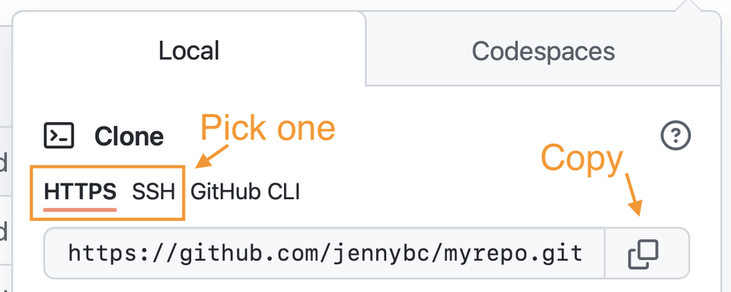

## Can you hear me?

3. **RStudio Project**
   - Launch RStudio
   - `File > New Project > Version Control > Git`
   - `Repository URL`: Paste GitHub URL
   - `Project directory name`: leave blank
   - `Create project as subdirectory of`: browse to this course main folder in your computer (where you see other project folders like `01_intro`)
   - `Create Project`

## Can you hear me?

4. **From changes to commits**
   - From RStudio, launch your README, edit it, save it
   - Can you see the Git pane next to the environment? If not, then do `View > Show git`
   - Under `Staged`, check the box for `README.md`
   - Click on the checkmark icon (to commit)
   - Under `commit message`, write something short yet informative (e.g., updated readme)
   - Click on `Commit`, close log window

## Can you hear me?

5. **Push to GitHub**
- Back on `Git` pane, click on the green up arrow to push your changes
- Close log window
- On browser, refresh github repo page

## Did you hear me?

Did it all work? If yes, then you are all set to use git and GitHub! 🥳

If not, then we’ll need to troubleshoot it.

## Forking the class `2026_dsa` repo

Next, let’s **Fork and Clone** the class repo, so you won’t need to do manual downloads anymore.

Detailed instructions found [here](https://happygitwithr.com/fork-and-clone.html?q=fork#fork-and-clone-create-from-github)

## Forking the class `2026_dsa` repo

1. **Copying the URL**
   - Go to the class repo https://github.com/leombastos/2026_dsa
   - Click on the <> Code button
   - Choose HTTPS
   - Copy the path

## Forking the class `2026_dsa` repo

2. **Forking and cloning with {usethis}**
- Open any RStudio window
- On the console, copy the code below (copy button on top right corner), edit `destdir` and run in the console:

```r
usethis::create_from_github(
  "https://github.com/leombastos/2026_dsa.git",
  destdir = "~/path/to/where/you/want/the/local/repo/",
  fork = TRUE)
```

## Forking the class `2026_dsa` repo

Now, anytime I have new code or data files, all you need to do is:

- Launch that RStudio Project
- On the `Git` pane, click on the green down arrow to pull the updates
- Move your local copies of the new files into your own project folder and appropriate sub-folders